# IODS course project

Annika Lehmus-Sun

## Welcome to my course diary!

#### The aim of the Open Data course is (at leas for me) to answer the questions of new kind of open data that we have all around us. It will give one tools to work with the great amount of open data that is available - to help one to analyze and play with the data. https://github.com/AnnikaLehmusSun/IODS-project

# Regression and model validation

```
## 'data.frame':    166 obs. of  7 variables:
##  $ gender  : Factor w/ 2 levels "F","M": 1 2 1 2 2 1 2 1 2 1 ...
##  $ Age     : int  53 55 49 53 49 38 50 37 37 42 ...
##  $ Attitude: int  37 31 25 35 37 38 35 29 38 21 ...
##  $ deep    : num  3.58 2.92 3.5 3.5 3.67 ...
##  $ stra    : num  3.38 2.75 3.62 3.12 3.62 ...
##  $ surf    : num  2.58 3.17 2.25 2.25 2.83 ...
##  $ Points  : int  25 12 24 10 22 21 21 31 24 26 ...
```

```
## [1] 166   7
```

#### Next I will present a graphical overview of the dataset “learning2014”. The graph below gives hints of correlations between variables. According to the graph, it seems that there are rather little correlations between the learning approaches, gender and age with the exam points. Contrary, the strongest correlation is with the atttitude and points.

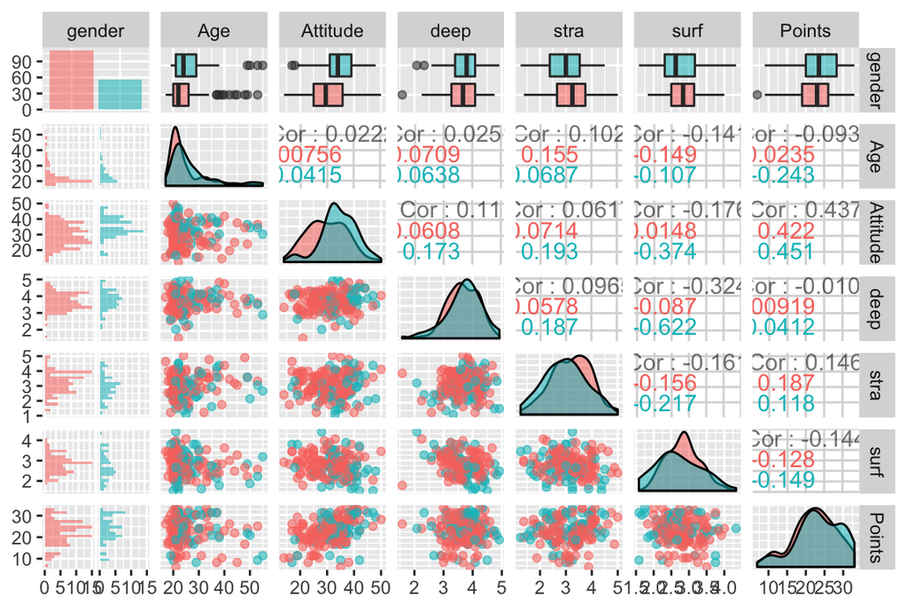

#### Based on the graphical overview of the data, it seems that attitude correlates greatly with points. Let’s take a closer look of all the variables:

#### gender: The data is based on information from 110 female and 56 male students.

```
##   F   M
## 110  56
```

#### age: the youngest respondents is 17-year-old, and oldest 55-year-old, mean age being 25,5-year-old.

```
##    Min. 1st Qu.  Median    Mean 3rd Qu.    Max.
##   17.00   21.00   22.00   25.51   27.00   55.00
```

#### attitude towards statistics: the attitude is shown in likert-scale 1-5. Amond the students the lowest attitude values was 1.4 and highest 5.

```
##    Min. 1st Qu.  Median    Mean 3rd Qu.    Max.
##   1.400   2.600   3.200   3.143   3.700   5.000
```

#### Learning approaches (deep, strategic and surface) are each measusered in likert-scale 1-5:

1. deep learning approach: the lowest values given is 1.6 and the highest 4.9. Mean is 3.7. Altogether 157/166 respodents.

```
##    Min. 1st Qu.  Median    Mean 3rd Qu.    Max.
##   1.583   3.333   3.667   3.680   4.083   4.917
```

#### (2) strategic learning approach: the lowest value given is 1.2 and the highest 5.0. Mean is 3.1. Altohether 161/166 respodents.

```
##    Min. 1st Qu.  Median    Mean 3rd Qu.    Max.
##   1.250   2.625   3.188   3.121   3.625   5.000
```

#### (3) surface learning approach: the lowest value given is 1.6 and the highest 4.3. Mean is 2.8. Altogether 157/166 respodents.

```
##    Min. 1st Qu.  Median    Mean 3rd Qu.    Max.
##   1.583   2.417   2.833   2.787   3.167   4.333
```

#### Of all the learning approaches the approach deep seems to get the highest (3.7) median value, and the approach surface the lowest (2.8).

#### exam points: the lowest amount is 7 and the highest 33 points. Median value is approximately 23.

```
##    Min. 1st Qu.  Median    Mean 3rd Qu.    Max.
##    7.00   19.00   23.00   22.72   27.75   33.00
```

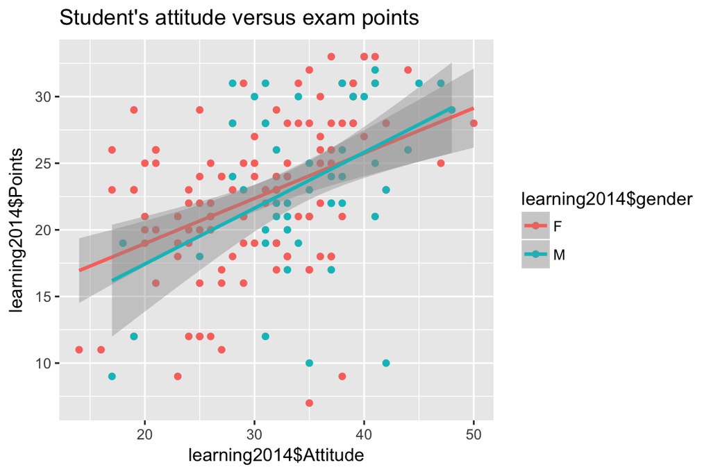

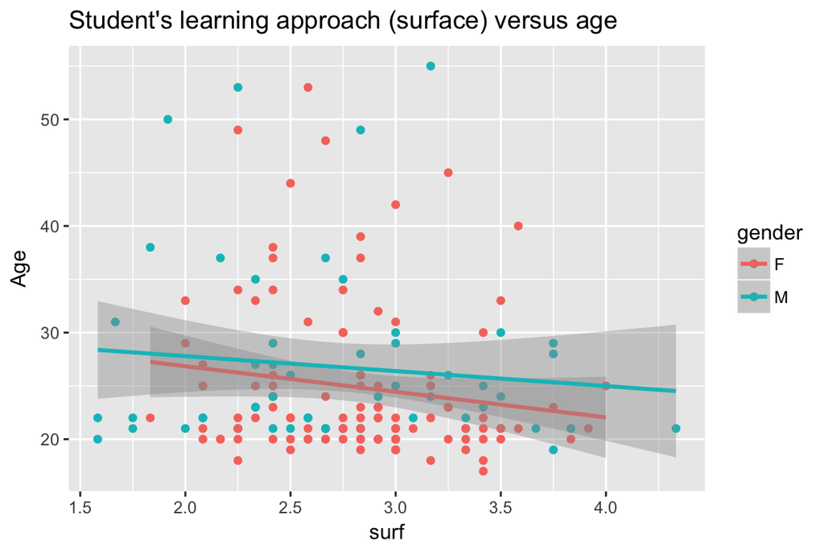

### Regression analysis: relationship of attitude, deep learning approach, age, and exam points as a dependent

#### Regression model and analysis is probably one of hte most used method for predicting correlations between variables - to understand how certain independent variables (in my model that is attitude, deep learning approach and age) are related to the dependent variable (that is in this model examp points). Regression analysis helps to investigate different dimensions of the relationship and correlations. However, it is good to keep in mind that correlation does not (always) mean causality. (Armstrong, 2012.) The model1 (below) shows the correlations of the independent variable and dependent variable.

```
##
## Call:
## lm(formula = Points ~ Attitude + deep + Age, data = learning2014)
##
## Residuals:
##     Min      1Q  Median      3Q     Max
## -17.206  -3.430   0.204   3.979  10.950
##
## Coefficients:
##             Estimate Std. Error t value Pr(>|t|)
## (Intercept) 15.60773    3.38966   4.605 8.32e-06 ***
## Attitude     0.35941    0.05696   6.310 2.56e-09 ***
## deep        -0.60275    0.75031  -0.803    0.423
## Age         -0.07716    0.05322  -1.450    0.149
## ---
## Signif. codes:  0 '***' 0.001 '**' 0.01 '*' 0.05 '.' 0.1 ' ' 1
##
## Residual standard error: 5.307 on 162 degrees of freedom
## Multiple R-squared:  0.2043, Adjusted R-squared:  0.1896
## F-statistic: 13.87 on 3 and 162 DF,  p-value: 4.305e-08
```

#### P value tells us yet something about existing correlation. Therefore, let’s take a closer look at regression model “model2”, where attitude towards statistics is an independent variable (since it was the only one with a statistical significance) and exam points a dependent variable:

```r
model2 <- lm(Points ~ Attitude, data = learning2014)
summary(model2)
```

```
##
## Call:
## lm(formula = Points ~ Attitude, data = learning2014)
##
## Residuals:
##      Min       1Q   Median       3Q      Max
## -16.9763  -3.2119   0.4339   4.1534  10.6645
##
## Coefficients:
##             Estimate Std. Error t value Pr(>|t|)
## (Intercept) 11.63715    1.83035   6.358 1.95e-09 ***
## Attitude     0.35255    0.05674   6.214 4.12e-09 ***
## ---
## Signif. codes:  0 '***' 0.001 '**' 0.01 '*' 0.05 '.' 0.1 ' ' 1
##
## Residual standard error: 5.32 on 164 degrees of freedom
## Multiple R-squared:  0.1906, Adjusted R-squared:  0.1856
## F-statistic: 38.61 on 1 and 164 DF,  p-value: 4.119e-09
```

#### According to the model2, we can say that it seems like that, when the students’ attitude towards statistics rises also her/his exam point rises. The result is statistically significant (nevertheless, it is good to keep in mind Nuzzo’s argument of P value). The multiple R-squared of model2 is 0.19 (19%). R-squared measures how close the data is to the fitted regression line. It is the percentage of the response variable variation i.e. dependent variable, in model2 that is exam points, that is explained by a linear model. (Frost, 2013) Conclusively, attitude variable explains some variation of examp points, not extensively though.

#### Next I will provide following diagnostic plots: (1) Residuals vs Fitted values, (2) Normal QQ-plot and (3) Residuals vs Leverage. Residuals vs fitted values plot tells us how well the model (in this case model2) fits the data, and it could fit better. We find pretty equally spread residuals around horizontal line in Fitted values- plot, it is a indication that there is not non-linear relationship between exam points and attitude. In comparison, normal QQ-plot shows us if the residuals are normally distributed. According to the Tehroeticial Quonatiles - plot (below) shows how residuals are lined well on the straight dashed line, which means that they are quite normally distributed. The last one, Residual vs leverage plot shows possible influential cases. According to the Levarage -plot shows that there is not influential case(s), you can easily see that all the cases are inside Cook’s distance lines (if there was an influential case, it would show in the upper and lower right corner).

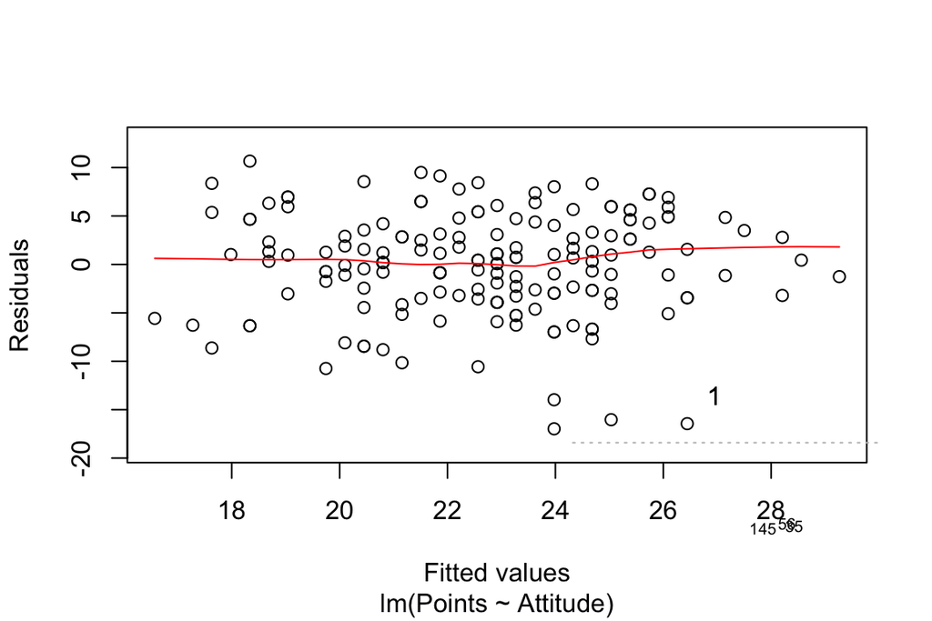

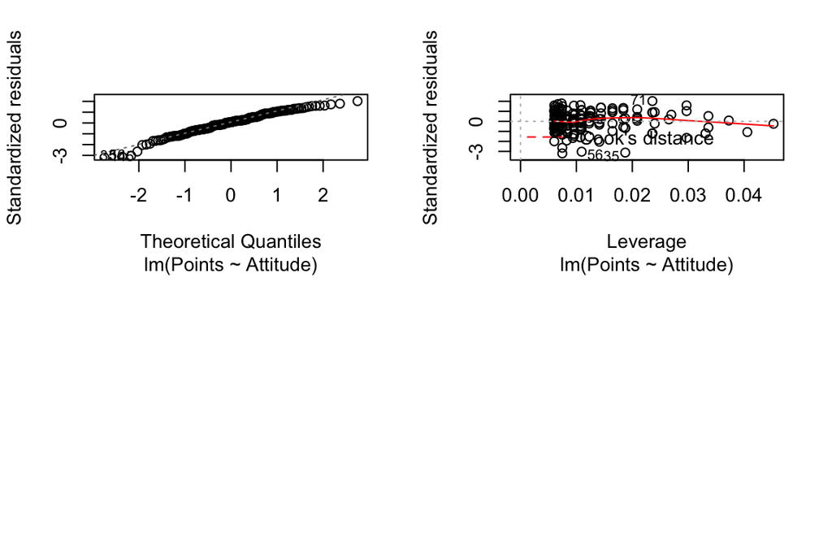

#### References:

#### Armstrong, J. (2002). Illusion in Regression Analysis. Forthcoming, International Journal of Forecasting. Philadelphia. Available at: http://www.academia.edu/1105970/Illusions_in_Regression_Analysis. Last accessed 29.1.2017

#### Frost, J. (2013). Regression Analysis: How Do I Interpret R-squared and Assess the Goodness-of-Fit?. The minitab blog. Available at: http://blog.minitab.com/blog/adventures-in-statistics-2/regression-analysis-how-do-i-interpret-r-squared-and-assess-the-goodness-of-fit. Last accessed 29.1.2017.

#### Nuzzo, R. (2014). Statistical errors. P values, ‘the gold standard’ of statistical validity, are not as reliable as many scientist assume. Nature. 306. 150-152.

#### Vehkalahti, K. (2015). The relationship between learning approaches and students’ achievements in an introductory statistics course in Finland. 60th World Statistics Congress, ISI2015. Rio de Janeiro.

# Logistic regression

#### The data that will be used in chapter 3 contains information of students and their alcohol usage. It provides correlation between different factors e.g. gender, age, study time and the use of alcohol. The data has altogether 382 observations and 35 variables, and it has information from both math course students and Portuguese language course students - hence, the data is consisted of two datasets.

```
## 'data.frame':    382 obs. of  35 variables:
##  $ school    : Factor w/ 2 levels "GP","MS": 1 1 1 1 1 1 1 1 1 1 ...
##  $ sex       : Factor w/ 2 levels "F","M": 1 1 1 1 1 2 2 1 2 2 ...
##  $ age       : int  18 17 15 15 16 16 16 17 15 15 ...
##  $ address   : Factor w/ 2 levels "R","U": 2 2 2 2 2 2 2 2 2 2 ...
##  $ famsize   : Factor w/ 2 levels "GT3","LE3": 1 1 2 1 1 2 2 1 2 1 ...
##  $ Pstatus   : Factor w/ 2 levels "A","T": 1 2 2 2 2 2 2 1 1 2 ...
##  $ Medu      : int  4 1 1 4 3 4 2 4 3 3 ...
##  $ Fedu      : int  4 1 1 2 3 3 2 4 2 4 ...
##  $ Mjob      : Factor w/ 5 levels "at_home","health",..: 1 1 1 2 3 4 3 3 4 3 ...
##  $ Fjob      : Factor w/ 5 levels "at_home","health",..: 5 3 3 4 3 3 3 5 3 3 ...
##  $ reason    : Factor w/ 4 levels "course","home",..: 1 1 3 2 2 4 2 2 2 2 ...
##  $ nursery   : Factor w/ 2 levels "no","yes": 2 1 2 2 2 2 2 2 2 2 ...
##  $ internet  : Factor w/ 2 levels "no","yes": 1 2 2 2 1 2 2 1 2 2 ...
##  $ guardian  : Factor w/ 3 levels "father","mother",..: 2 1 2 2 1 2 2 2 2 2 ...
```

[output cut: 21 more lines]

```
## [1] 382  35
```

#### Next I will analyze the relationship between low alcohol consumption age, sex, whether the student wants to aim higher education (higher) and final grade (G3). The hypothesis is that the younger the person is, and the higher of the final grade is, the less alcohol the student consumes. Moreover, my hypothesis is that the female students uses less alcohol and if the student aims to receive higher education in future, he/she uses less alcohol.

#### aims for higher education summary

```
##  no yes
##  18 364
```

#### Gender and age summaries

```
##   F   M
## 198 184
```

```
##    Min. 1st Qu.  Median    Mean 3rd Qu.    Max.
##   15.00   16.00   17.00   16.59   17.00   22.00
```

#### final grade summary

```
##    Min. 1st Qu.  Median    Mean 3rd Qu.    Max.
##    0.00   10.00   12.00   11.46   14.00   18.00
```

```
##
## Call:
## lm(formula = high_use ~ higher + age + sex + G3, data = alc)
##
## Residuals:
##     Min      1Q  Median      3Q     Max
## -0.6489 -0.3152 -0.2039  0.5366  0.9150
##
## Coefficients:
##              Estimate Std. Error t value Pr(>|t|)
## (Intercept) -0.200749   0.385385  -0.521 0.602739
## higheryes   -0.029996   0.116457  -0.258 0.796881
## age          0.036902   0.020130   1.833 0.067571 .
## sexM         0.178498   0.046309   3.854 0.000136 ***
## G3          -0.014861   0.007284  -2.040 0.042022 *
## ---
## Signif. codes:  0 '***' 0.001 '**' 0.01 '*' 0.05 '.' 0.1 ' ' 1
##
## Residual standard error: 0.4456 on 377 degrees of freedom
## Multiple R-squared:  0.06397,    Adjusted R-squared:  0.05404
## F-statistic: 6.442 on 4 and 377 DF,  p-value: 5.054e-05
```

[figure not shown]

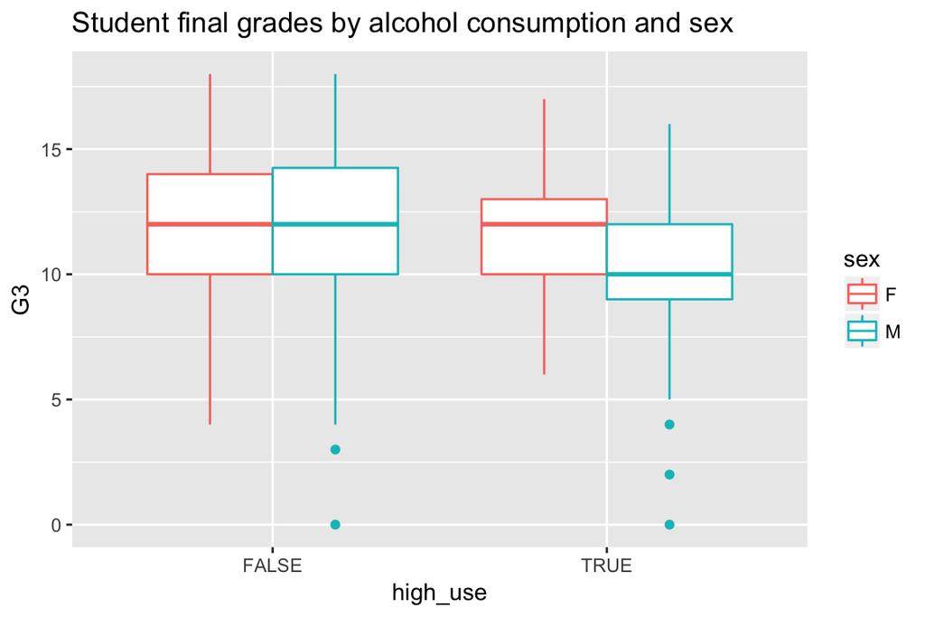

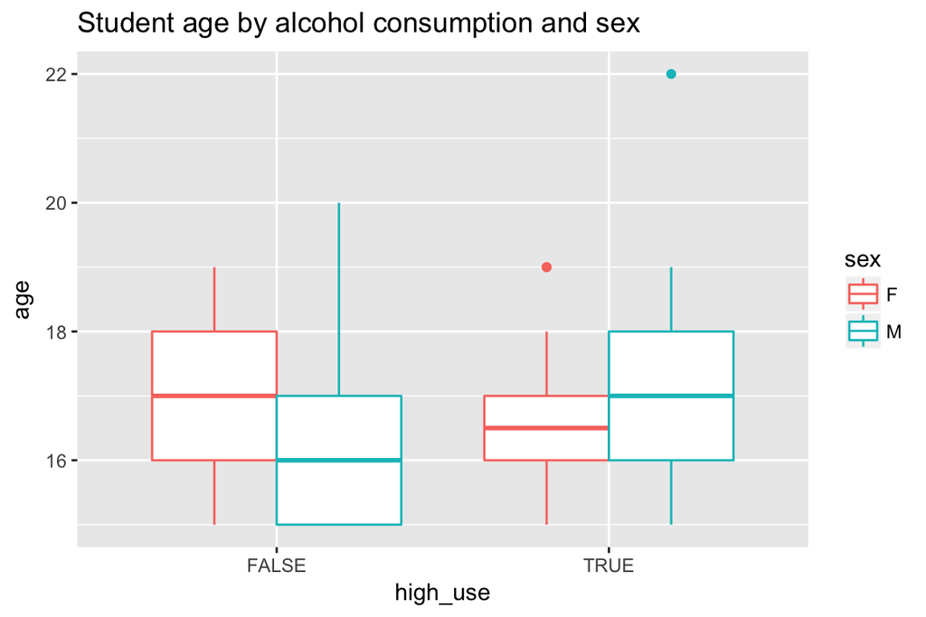

#### Below I have used logistic regression to study the same variables as above (i.e. relationship between alcohol consumption and age, gender, final grade and person’s aim for higher education). According to the logistic regression, the results are rather similar than with ordinary regression analysis. Although the confidence intervals shows that there, indeed, seem to be a strong correlation with the person’s gender and higher alcohol use (which is also agreeing with the hypothesis).

```
##
## Call:  glm(formula = high_use ~ higher + age + sex + G3, family = "binomial",
##     data = alc)
##
## Coefficients:
## (Intercept)    higheryes          age         sexM           G3
##    -3.40256     -0.06768      0.17849      0.88678     -0.07279
##
## Degrees of Freedom: 381 Total (i.e. Null);  377 Residual
## Null Deviance:       465.7
## Residual Deviance: 441.2     AIC: 451.2
```

```
##
## Call:
## glm(formula = high_use ~ higher + age + sex + G3, family = "binomial",
##     data = alc)
##
## Deviance Residuals:
##     Min       1Q   Median       3Q      Max
## -1.5339  -0.8527  -0.6714   1.2195   2.0443
##
## Coefficients:
##             Estimate Std. Error z value Pr(>|z|)
## (Intercept) -3.40256    1.92863  -1.764 0.077692 .
## higheryes   -0.06768    0.53866  -0.126 0.900008
## age          0.17849    0.10130   1.762 0.078087 .
## sexM         0.88678    0.23699   3.742 0.000183 ***
## G3          -0.07279    0.03687  -1.974 0.048379 *
## ---
## Signif. codes:  0 '***' 0.001 '**' 0.01 '*' 0.05 '.' 0.1 ' ' 1
##
## (Dispersion parameter for binomial family taken to be 1)
##
##     Null deviance: 465.68  on 381  degrees of freedom
## Residual deviance: 441.20  on 377  degrees of freedom
## AIC: 451.2
##
## Number of Fisher Scoring iterations: 4
```

```
## (Intercept)   higheryes         age        sexM          G3
## -3.40256416 -0.06768339  0.17848874  0.88678017 -0.07279062
```

```
##                     OR        2.5 %    97.5 %
## (Intercept) 0.03328781 0.0007336692 1.4376012
## higheryes   0.93455632 0.3231410944 2.7357882
## age         1.19540942 0.9811211394 1.4609460
## sexM        2.42730155 1.5322075526 3.8860179
## G3          0.92979549 0.8641844894 0.9989948
```

```
##
## Call:
## glm(formula = high_use ~ age + G3 + sex, family = "binomial",
##     data = alc)
##
## Deviance Residuals:
##     Min       1Q   Median       3Q      Max
## -1.5458  -0.8533  -0.6718   1.2150   2.0483
##
## Coefficients:
##             Estimate Std. Error z value Pr(>|z|)
## (Intercept) -3.49251    1.79024  -1.951 0.051073 .
## age          0.18078    0.09962   1.815 0.069564 .
## G3          -0.07412    0.03533  -2.098 0.035907 *
## sexM         0.89183    0.23359   3.818 0.000135 ***
## ---
## Signif. codes:  0 '***' 0.001 '**' 0.01 '*' 0.05 '.' 0.1 ' ' 1
##
## (Dispersion parameter for binomial family taken to be 1)
##
##     Null deviance: 465.68  on 381  degrees of freedom
## Residual deviance: 441.21  on 378  degrees of freedom
## AIC: 449.21
##
## Number of Fisher Scoring iterations: 4
```

```
##         prediction
## high_use FALSE TRUE
##    FALSE   260    8
##    TRUE    102   12
```

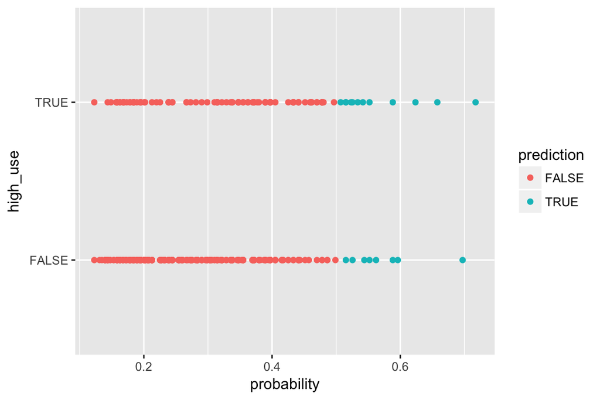

# Clustering and classification

#### The data I will be using in the following assignment is called Boston and it is about the housing values in suburbs of Boston. There are 14 variables of the data are: crim -crime rate; zn - proportion of residential land; indus - proportion of non-retail business acres; chas - Charles River dummy variable (= 1 if tract bounds river; 0 otherwise); nox - nitrogen oxides concentration; rm -average number of rooms per dwelling;age - proportion of owner-occupied units built prior to 1940; dis - weighted mean of distances to five Boston employment centres; rad - index of accessibility to radial highways; tax - full-value property-tax rate per $10,000; ptratio- pupil-teacher ratio by town; black- 1000(Bk - 0.63)^2 where Bk is the proportion of blacks by town; lstat -lower status of the population (percent); medv - median value of owner-occupied homes in $1000s. Below you can see the structure and dimensions of the data.

```r
library(MASS)
```

```r
data("Boston")
library(ggplot2)
library(corrplot)
library(tidyverse)
str(Boston)
```

```
## 'data.frame':    506 obs. of  14 variables:
##  $ crim   : num  0.00632 0.02731 0.02729 0.03237 0.06905 ...
##  $ zn     : num  18 0 0 0 0 0 12.5 12.5 12.5 12.5 ...
##  $ indus  : num  2.31 7.07 7.07 2.18 2.18 2.18 7.87 7.87 7.87 7.87 ...
##  $ chas   : int  0 0 0 0 0 0 0 0 0 0 ...
##  $ nox    : num  0.538 0.469 0.469 0.458 0.458 0.458 0.524 0.524 0.524 0.524 ...
##  $ rm     : num  6.58 6.42 7.18 7 7.15 ...
##  $ age    : num  65.2 78.9 61.1 45.8 54.2 58.7 66.6 96.1 100 85.9 ...
##  $ dis    : num  4.09 4.97 4.97 6.06 6.06 ...
##  $ rad    : int  1 2 2 3 3 3 5 5 5 5 ...
##  $ tax    : num  296 242 242 222 222 222 311 311 311 311 ...
##  $ ptratio: num  15.3 17.8 17.8 18.7 18.7 18.7 15.2 15.2 15.2 15.2 ...
##  $ black  : num  397 397 393 395 397 ...
##  $ lstat  : num  4.98 9.14 4.03 2.94 5.33 ...
##  $ medv   : num  24 21.6 34.7 33.4 36.2 28.7 22.9 27.1 16.5 18.9 ...
```

```r
dim(Boston)
```

```
## [1] 506  14
```